# SiqueiraCampos_wk5

Marco Siqueira Campos

1 de outubro de 2016

DATA 607 MSDA CUNY

ASSIGNMENT WK5  
Tidying and Transforming Data

github [link](https://github.com/MarcoSCampos/DATA_607)

Load Library

```r
library(tidyr)
library(dplyr)
library(lattice)
```

**1- Create .CSV file**  
The file was created in MySQL database and the script is available at Github link, see above.

**2- Read .CSV file**

Read and check csv file

```r
df_td<-read.table("~/mysql_td.csv", sep=",", stringsAsFactors = FALSE)
df_td
```

```
##       V1      V2          V3      V4        V5            V6      V7
## 1     v1      v2          v3      v4        v5            v6      v7
## 2                Los Angeles Phoenix San Diego San Francisco Seattle
## 3 ALASKA on time         497     221       212           503   1,841
## 4        delayed          62      12        20           102     305
## 5
## 6 AMWEST on time         694   4,840       383           320     201
## 7        delayed         117     415        65           129      61
```

Cleannig the file:

remove unnecessary rows

```r
df_td<-df_td[-c(1,5),]
```

adjust the column names and reply (fill the spaces) at the airline name

```r
df_td[3,1]<-'ALASKA'
df_td[5,1]<-'AMWEST'
colnames(df_td)[3:7]<-df_td[1,3:7]
df_td<-df_td[-1,]
```

check the results

```r
df_td
```

```
##       V1      V2 Los Angeles Phoenix San Diego San Francisco Seattle
## 3 ALASKA on time         497     221       212           503   1,841
## 4 ALASKA delayed          62      12        20           102     305
## 6 AMWEST on time         694   4,840       383           320     201
## 7 AMWEST delayed         117     415        65           129      61
```

The data is not tidy, we have variable in rows and the same variable in several columns.  
The next steps is to data tidy.

First step is the gather the data

```r
df_td2<-gather(df_td,"city","time",3:7)
colnames(df_td2)[1]<-"airline"
```

Removing the comma at the data and change from character to numeric.

```r
df_td2$time<-as.numeric(gsub(",","",df_td2$time))
```

Check the results

```r
df_td2
```

```
##    airline      V2          city time
## 1   ALASKA on time   Los Angeles  497
## 2   ALASKA delayed   Los Angeles   62
## 3   AMWEST on time   Los Angeles  694
## 4   AMWEST delayed   Los Angeles  117
## 5   ALASKA on time       Phoenix  221
## 6   ALASKA delayed       Phoenix   12
## 7   AMWEST on time       Phoenix 4840
## 8   AMWEST delayed       Phoenix  415
## 9   ALASKA on time     San Diego  212
## 10  ALASKA delayed     San Diego   20
## 11  AMWEST on time     San Diego  383
## 12  AMWEST delayed     San Diego   65
## 13  ALASKA on time San Francisco  503
## 14  ALASKA delayed San Francisco  102
## 15  AMWEST on time San Francisco  320
## 16  AMWEST delayed San Francisco  129
## 17  ALASKA on time       Seattle 1841
## 18  ALASKA delayed       Seattle  305
## 19  AMWEST on time       Seattle  201
## 20  AMWEST delayed       Seattle   61
```

Spreading one variable, we have one column mixing two variables, V2.

```r
df_td3<-spread(df_td2,V2,time)
```

Change one name to facilitate data manipulation.  
Change ‘airline’ to factor.  
Check the results, data is tidy.

```r
df_td3['airline']<-lapply(df_td3['airline'], factor)
colnames(df_td3)[4]<-"on_time"
df_td3
```

```
##    airline          city delayed on_time
## 1   ALASKA   Los Angeles      62     497
## 2   ALASKA       Phoenix      12     221
## 3   ALASKA     San Diego      20     212
## 4   ALASKA San Francisco     102     503
## 5   ALASKA       Seattle     305    1841
## 6   AMWEST   Los Angeles     117     694
## 7   AMWEST       Phoenix     415    4840
## 8   AMWEST     San Diego      65     383
## 9   AMWEST San Francisco     129     320
## 10  AMWEST       Seattle      61     201
```

The data now is tidy.

**3-Perform analysis to compare the arrival delays for the two airlines.**

Add one more column to analyse the performance, on time arrival proportion

On time proportion.

```r
df_td3<-mutate(df_td3, ontime_pro=round((on_time/(on_time+ delayed)*100), digits=1))
df_td3
```

```
##    airline          city delayed on_time ontime_pro
## 1   ALASKA   Los Angeles      62     497       88.9
## 2   ALASKA       Phoenix      12     221       94.8
## 3   ALASKA     San Diego      20     212       91.4
## 4   ALASKA San Francisco     102     503       83.1
## 5   ALASKA       Seattle     305    1841       85.8
## 6   AMWEST   Los Angeles     117     694       85.6
## 7   AMWEST       Phoenix     415    4840       92.1
## 8   AMWEST     San Diego      65     383       85.5
## 9   AMWEST San Francisco     129     320       71.3
## 10  AMWEST       Seattle      61     201       76.7
```

The first step is analyse the aggregated data about arrival delayed data by airline.

On time proportion by airline.

```r
df_td3%>%
   group_by(airline)%>%
   summarise(count=round(100*(sum(on_time)/(sum(delayed)+sum(on_time))), digits=1))
```

```
## # A tibble: 2 x 2
##   airline count
##    <fctr> <dbl>
## 1  ALASKA  86.7
## 2  AMWEST  89.1
```

The aggregated data show the performance about on time arrival, the AMWEST airline is better, had 89.1% at on time arrival.

Next step is check the partioned data by city.

```r
df_td3%>%
   group_by(airline, city)%>%
   summarise(count=round(100*(sum(on_time)/(sum(delayed)+sum(on_time))), digits=1))
```

```
## Source: local data frame [10 x 3]
## Groups: airline [?]
##
##    airline          city count
##     <fctr>         <chr> <dbl>
## 1   ALASKA   Los Angeles  88.9
## 2   ALASKA       Phoenix  94.8
## 3   ALASKA     San Diego  91.4
## 4   ALASKA San Francisco  83.1
## 5   ALASKA       Seattle  85.8
## 6   AMWEST   Los Angeles  85.6
## 7   AMWEST       Phoenix  92.1
## 8   AMWEST     San Diego  85.5
## 9   AMWEST San Francisco  71.3
## 10  AMWEST       Seattle  76.7
```

To improve the data analysis is better to see the data in barplot graph.

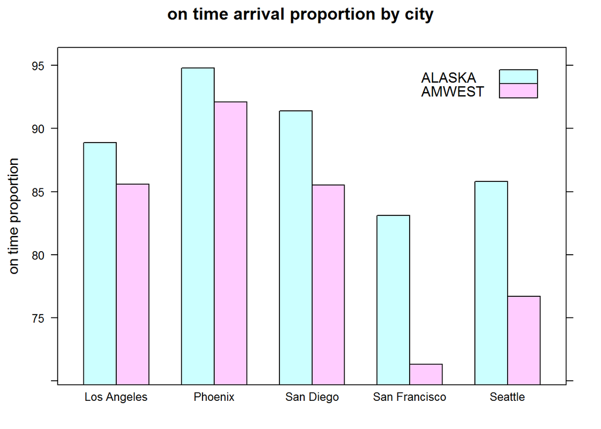

```r
barchart(ontime_pro~city, data=df_td3, groups=airline, main="on time arrival proportion by city",
         auto.key = list(x = .7, y = .85, corner = c(0, 0), pch=22), ylab="on time proportion")
```

The table and the graphs show the performance in on time arrival partitioned by city, the ALASKA airline is better.

The results is apparently confused, in aggregate data AMWEST is better however when the data is partitioned by city ALASKA is better. We had here in the data the effects of Simpson’s paradox, in which a trend appears in different groups of data but reverses when theses groups is combined. See more about Simpson’s paradox [wikipedia](https://en.wikipedia.org/wiki/Simpson%27s_paradox)

In this assignment the root cause is due the data unbalance, the quantity of AMWEST flights at Phoenix, 5255, this leads a data distortion, when the data are aggredated.

In the performance by city, we can say that ALASKA airline has a better performance at on time arrival, for this reason I can say that the ALASKA airline has better performance.